# Corpus Analysis and Visualization

Wouter van Atteveldt  
Glasgow Text Analysis, 2016-11-17

### Course Overview

10:30 - 12:00

- Recap: Frequency Based Analysis and the DTM
- Dictionary Analysis with AmCAT and R

13:30 - 15:00

- *Simple Natural Language Processing*
- Corpus Analysis and Visualization
- Topic Modeling and Visualization

15:15 - 17:00

- Sentiment Analysis with dictionaries
- Sentiment Analysis with proximity

### Simple NLP

- Preprocess documents to get more information
- Relatively fast and accurate
  - Lemmatizing
  - Part-of-Speech (POS) tagging
  - Named Entity Recognition
- Unfortunately, not within R

### NLPipe + nlpiper

- nlpipe: simple NLP processing based on stanford corenlp, others

```bash
docker run -dp 5001:5001 vanatteveldt/nlpipe
docker run -dp 9000:9000 chilland/corenlp-docker
```

```r
devtools::install_github("vanatteveldt/nlpiper")
```

```r
library(nlpiper)
process("test_upper", "test")
```

```
[1] "TEST"
```

### Corenlp POS+lemma+NER

```r
library(nlpiper)
text = "Donald trump was elected president of the United States"
process("corenlp_lemmatize", text, format="csv")
```

```
  sentence offset      word     lemma  POS POS1      ner
1        1      0    Donald    Donald  NNP    R   PERSON
2        1      7     trump     trump  NNP    R   PERSON
3        1     13       was        be  VBD    V        O
4        1     17   elected     elect  VBN    V        O
5        1     25 president president   NN    N        O
6        1     35        of        of   IN    P        O
7        1     38       the       the   DT    D        O
8        1     42    United    United  NNP    R LOCATION
9        1     49    States    States NNPS    R LOCATION
```

### NLPiper and US elections

- Nlpipe and especially the r library is very much work in progress
- Can only do one document at a time from R
- Download tokens for US elections:

```r
# choose one:
download.file("http://i.amcat.nl/tokens.rds", "tokens.rds")
download.file("http://i.amcat.nl/tokens_full.rds", "tokens.rds")
download.file("http://i.amcat.nl/tokens_sample.rds", "tokens.rds")
```

```r
tokens = readRDS("tokens.rds")
Head(tokens)
```

|  | id | sentence | offset | word | lemma | POS | POS1 | ner |
| --- | --- | --- | --- | --- | --- | --- | --- | --- |
| 78757 | 162317736 | 1 | 0 | New | New | NNP | R | O |
| 78758 | 162317736 | 1 | 4 | Technologies | Technologies | NNP | R | O |
| 78759 | 162317736 | 1 | 17 | Give | give | VB | V | O |
| 78760 | 162317736 | 1 | 22 | Government | Government | NNP | R | O |
| 78761 | 162317736 | 1 | 33 | Ample | Ample | NNP | R | O |
| 78762 | 162317736 | 1 | 39 | Means | Means | NNP | R | O |

## Corpus Analysis

### Corpus Analysis

- Exploratory Analysis
- Term statistics
- Corpus comparison

The corpustools package

- Useful functions for corpus analysis
- Not fully integrated with quanteda
  - (we're working on it :) )

```r
devtools::install_github("kasperwelbers/corpus-tools")
```

### Dtm vs Dfm

- quanteda uses 'dfm' objects
  - document-feature matrix
- tm uses 'dtm' objects
  - document-term matrix
- Both are sparse matrices

### Dtm vs dfm

```r
library(quanteda)
dfm = dfm(c("a text", "and another text"))
dtm = convert(dfm, "tm")
class(dtm)
```

```
[1] "DocumentTermMatrix"    "simple_triplet_matrix"
```

```r
library(corpustools)
dfm = dtm.to.dfm(dtm)
class(dfm)
```

```
[1] "dfmSparse"
attr(,"package")
[1] "quanteda"
```

### Create DTM from tokens

```r
dtm = dtm.create(tokens$id, tokens$lemma)
dtm.names = with(subset(tokens, POS1=="R"),
                 dtm.create(id, lemma))
dtm.adj = with(subset(tokens, POS1=="G"),
               dtm.create(id, lemma))
dtm.persons = with(subset(tokens, ner=="PERSON"),
                   dtm.create(id, lemma))
```

### Term statistics

```r
stats = term.statistics(dtm.persons)
stats = plyr::arrange(stats, -termfreq)
Head(stats)
```

| term | characters | number | nonalpha | termfreq | docfreq | reldocfreq | tfidf |
| --- | --- | --- | --- | --- | --- | --- | --- |
| Trump | 5 | FALSE | FALSE | 5237 | 674 | 0.6884576 | 0.1292291 |
| Clinton | 7 | FALSE | FALSE | 3357 | 582 | 0.5944842 | 0.1245666 |
| Donald | 6 | FALSE | FALSE | 1087 | 643 | 0.6567926 | 0.0423986 |
| Obama | 5 | FALSE | FALSE | 1082 | 318 | 0.3248212 | 0.1741539 |
| Sanders | 7 | FALSE | FALSE | 1040 | 190 | 0.1940756 | 0.3669743 |
| Hillary | 7 | FALSE | FALSE | 892 | 496 | 0.5066394 | 0.0650328 |

### Corpus Comparison

```r
meta = readRDS("meta.rds")
nyt1 = meta$id[meta$medium == "The New York Times" & meta$date < "2016-08-01"]
nyt2 = meta$id[meta$medium == "The New York Times" & meta$date >= "2016-08-01"]
dtm1 = with(subset(tokens, id %in% nyt1 & POS1=="G"), dtm.create(id, lemma))
dtm2 = with(subset(tokens, id %in% nyt2 & POS1=="G"), dtm.create(id, lemma))
cmp = corpora.compare(dtm1, dtm2)
cmp = plyr::arrange(cmp, -chi)
Head(cmp)
```

| term | termfreq.x | termfreq.y | termfreq | relfreq.x | relfreq.y | over | chi |
| --- | --- | --- | --- | --- | --- | --- | --- |
| presumptive | 63 | 0 | 63 | 0.0023287 | 0.0000606 | 38.4190954 | 37.69604 |
| russian | 33 | 66 | 99 | 0.0012371 | 0.0040611 | 0.3046290 | 36.30182 |
| hispanic | 27 | 57 | 84 | 0.0010188 | 0.0035156 | 0.2897992 | 33.34656 |
| brazilian | 0 | 17 | 17 | 0.0000364 | 0.0010910 | 0.0333499 | 28.46516 |
| racist | 0 | 16 | 16 | 0.0000364 | 0.0010304 | 0.0353117 | 26.79011 |
| incumbent | 0 | 15 | 15 | 0.0000364 | 0.0009698 | 0.0375186 | 25.11513 |

## Visualization

### Visualization

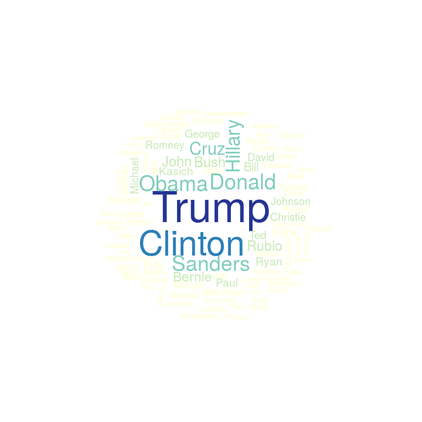

```r
dtm.wordcloud(dtm.persons, freq.fun = sqrt)
```

### Beyond (stupid) word clouds

- Word clouds waste most information
- `corpustools::plotWords`
  - specify x, y, colour, size, etc.
- Use any analytics you have to determine characteristics
- See also http://vanatteveldt.com/lse-text-visualization/

### Visualizing comparisons

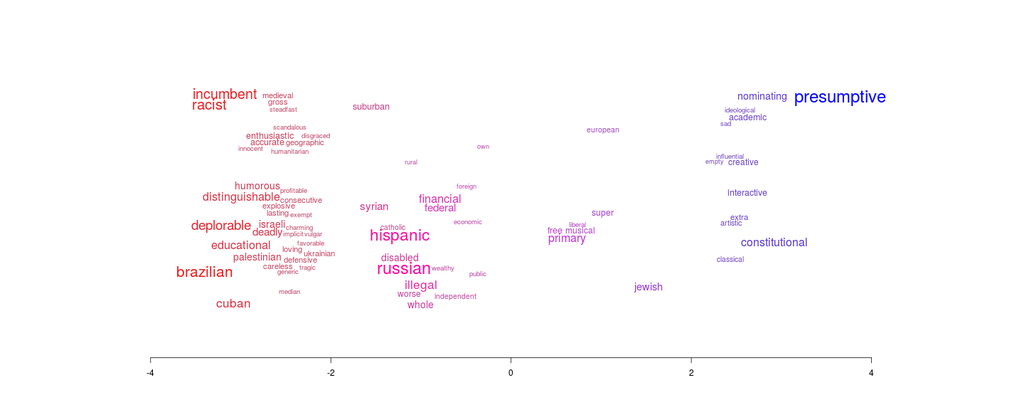

```r
h = rescale(log(cmp$over), c(1, .6666))
s = rescale(sqrt(cmp$chi), c(.25,1))
cmp$col = hsv(h, s, .33 + .67*s)
cmp = arrange(cmp, -chi)
with(head(cmp, 75), plotWords(x=log(over), words=term, wordfreq=chi, random.y = T, col=col, scale=2))
```

### Visualizing over time

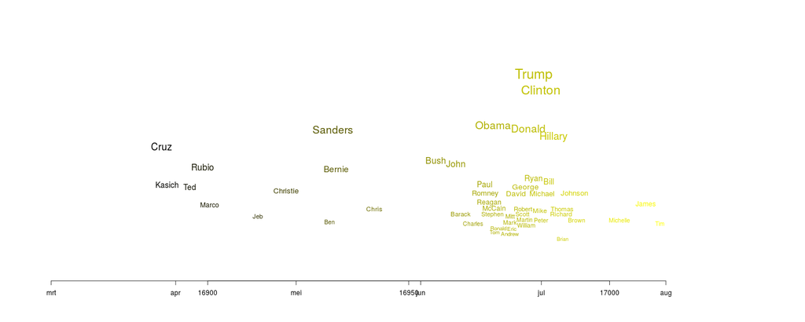

```r
terms = term.statistics(dtm.persons)

wordfreqs = dtm.to.df(dtm.persons)
wordfreqs = merge(meta, wordfreqs, by.x="id", by.y="doc")
dates = aggregate(wordfreqs["date"], by=wordfreqs["term"], FUN=mean)
terms = merge(terms, dates)
terms = plyr::arrange(terms, -docfreq)
with(head(terms, 50), plotWords(words=term, x=date, wordfreq = termfreq))
axis(1)
```

## Topic Modeling

### Topic Models

```r
dtm = with(subset(tokens, POS1 %in% c("G", "N", "V")),
                 dtm.create(id, lemma, minfreq = 10))
dtm = dtm[, !colnames(dtm) %in% tm::stopwords()]
set.seed(1234)
m = lda.fit(dtm, K = 10, num.iterations = 50, alpha=0.5)
Head(terms(m, 10))
```

| Topic 1 | Topic 2 | Topic 3 | Topic 4 | Topic 5 | Topic 6 | Topic 7 | Topic 8 | Topic 9 | Topic 10 |
| --- | --- | --- | --- | --- | --- | --- | --- | --- | --- |
| make | say | year | debate | country | tax | show | say | voter | say |
| city | people | first | media | will | say | art | campaign | win | email |
| work | get | show | political | people | year | include | presidential | vote | official |
| can | woman | play | question | american | will | exhibition | republican | state | case |
| take | think | write | use | police | company | work | convention | candidate | report |
| come | can | family | time | gun | job | artist | know | republican | year |

Visualizing Topic Models: LDAvis

```r
install.packages(c("LDAvis", "servr"))
library(LDAvis)
dtm = dtm[row_sums(dtm) > 0,]
json = ldavis_json(m, dtm)
LDAvis::serVis(json)
```

### Visualizing Topic Models: heat map

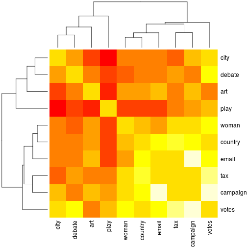

```r
topics = c("city", "woman", "play", "debate", "country", "tax", "art", "campaign", "votes", "email")
cm = cor(t(m@beta))
colnames(cm) = rownames(cm) = topics
diag(cm) = 0
heatmap(cm, symm = T)
```

### Visualizing Topic Models: word clouds

```r
compare.topics <- function(m, cmp_topics) {
  docs = factor(m@wordassignments$i, labels=m@documents)
  terms = factor(m@wordassignments$j, labels=m@terms)
  assignments = data.frame(doc=docs, term=terms, freq=m@wordassignments$v)
  terms = dcast(assignments, term ~ freq, value.var = "doc", fun.aggregate = length)
  terms = terms[, c(1, cmp_topics+1)]
  terms$freq = rowSums(terms[-1])
  terms = terms[terms$freq > 0,]
  terms$prop = terms[[2]] / terms$freq
  terms$col = hsv(rescale(terms$prop, c(1, .6666)), .5, .5)
  terms[order(-terms$freq), ]
}
```

### Visualizing Topic Models: word clouds

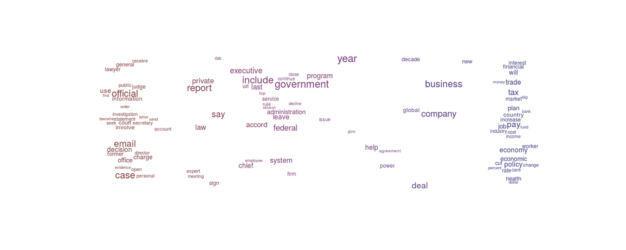

```r
terms = compare.topics(m, match(c("tax", "email"), topics))
with(head(terms, 100), plotWords(x=prop, wordfreq = freq, words = term, col=col, xaxt="none", random.y = T, scale=2))
```

### Analysing Topic Models

```r
tpd = topics.per.document(m)
colnames(tpd)[-1] = topics
tpd = merge(meta, tpd)
Head(tpd)
```

| id | date | medium | year | month | week | city | woman | play | debate | country | tax | art | campaign | votes | email |
| --- | --- | --- | --- | --- | --- | --- | --- | --- | --- | --- | --- | --- | --- | --- | --- |
| 162317736 | 2016-02-01 | The New York Times | 2016-01-01 | 2016-02-01 | 2016-02-01 | 0.2146172 | 0.0916473 | 0.0313225 | 0.1125290 | 0.0336427 | 0.0452436 | 0.0290023 | 0.0243619 | 0.0243619 | 0.3932715 |
| 162317809 | 2016-01-25 | The New York Times | 2016-01-01 | 2016-01-01 | 2016-01-25 | 0.1926752 | 0.0843949 | 0.0684713 | 0.1066879 | 0.0302548 | 0.1385350 | 0.0270701 | 0.0175159 | 0.0143312 | 0.3200637 |
| 171932192 | 2016-07-04 | The New York Times | 2016-01-01 | 2016-07-01 | 2016-07-04 | 0.1936416 | 0.0028902 | 0.0838150 | 0.1011561 | 0.0722543 | 0.2341040 | 0.0202312 | 0.0028902 | 0.0260116 | 0.2630058 |
| 171932219 | 2016-07-03 | The New York Times | 2016-01-01 | 2016-07-01 | 2016-06-27 | 0.0538793 | 0.5107759 | 0.0969828 | 0.1099138 | 0.1185345 | 0.0323276 | 0.0237069 | 0.0280172 | 0.0193966 | 0.0064655 |
| 171932226 | 2016-07-03 | The New York Times | 2016-01-01 | 2016-07-01 | 2016-06-27 | 0.0454545 | 0.1363636 | 0.0454545 | 0.2272727 | 0.2272727 | 0.0454545 | 0.0454545 | 0.0454545 | 0.0454545 | 0.1363636 |
| 171932227 | 2016-07-03 | The New York Times | 2016-01-01 | 2016-07-01 | 2016-06-27 | 0.1089385 | 0.2597765 | 0.2877095 | 0.0418994 | 0.0083799 | 0.0027933 | 0.0586592 | 0.1480447 | 0.0363128 | 0.0474860 |

## Hands-on session II

- Corpus analysis of Election campaign
  - (or your own data…)
- Which words, adjectives, verbs, etc are frequent?
- How do they differ over time, by medium, subcorpus
- What topics can we find?
- Can we visualize topics, contrasts, etc.